# Reproducible Research Peer Assessment - Storm Data

Tom Polak

December 18, 2017

## 1. Synopsis

The National Oceanic and Atmospheric Administration (NOAA) maintains a public database for storm events. The data contains the type of storm event, details like location, date, estimates for damage to property as well as the number of human victims of the storm. In this report we investigate which type of events are the most harmful to the population and financially.

## 2. Data Processing

2.1 First need to library the right packages

```r
library(tidyverse)
library(ggplot2)

library(grid) # Will use for two grids later
library(gridExtra) # for advanced plots
```

2.2 Load the raw dataset

```r
# Pull in the necessary tables

StormCSV <- read.csv(bzfile("StormData.csv.bz2"))
```

2.3 Tidy the raw data

```r
NecessaryColumns <- c('EVTYPE', 'FATALITIES', 'INJURIES', 'PROPDMG', 'PROPDMGEXP', 'CROPDMG', 'CROPDMGEXP')

# Keep only the necessary columns
StormData <- StormCSV[ , NecessaryColumns]

# Transforms the property damage and corp damage variables into absolute values
cleanStormData <- StormData %>%
  mutate(
      propDamage = PROPDMG * 10^case_when(
        grepl("h",PROPDMGEXP,ignore.case=TRUE) ~ 2,
        grepl("k",PROPDMGEXP,ignore.case=TRUE) ~ 3,
        grepl("m",PROPDMGEXP,ignore.case=TRUE) ~ 6,
        grepl("b",PROPDMGEXP,ignore.case=TRUE) ~ 9,
        TRUE ~ 0
        ),
      cropDamage = CROPDMG * 10^case_when(
        grepl("h",CROPDMGEXP,ignore.case=TRUE) ~ 2,
        grepl("k",CROPDMGEXP,ignore.case=TRUE) ~ 3,
        grepl("m",CROPDMGEXP,ignore.case=TRUE) ~ 6,
        grepl("b",CROPDMGEXP,ignore.case=TRUE) ~ 9,
        TRUE ~ 0
        ),
      totalDamage = propDamage + cropDamage,
      damageSource = NA
      )

# Combines the EVTYPE column into 11 different categories for damageSource
cleanStormData[grepl("precipitation|rain|hail|drizzle|wet|percip|burst|depression|fog|wall cloud",
                       cleanStormData$EVTYPE, ignore.case = TRUE), "damageSource"] <- "Precipitation & Fog"
cleanStormData[grepl("wind|storm|wnd|hurricane|typhoon",
                       cleanStormData$EVTYPE, ignore.case = TRUE), "damageSource"] <- "Wind & Storm"
cleanStormData[grepl("slide|erosion|slump",
                       cleanStormData$EVTYPE, ignore.case = TRUE), "damageSource"] <- "Landslide & Erosion"
cleanStormData[grepl("warmth|warm|heat|dry|hot|drought|thermia|temperature record|record temperature|record high",
                       cleanStormData$EVTYPE, ignore.case = TRUE), "damageSource"] <- "Heat & Drought"
cleanStormData[grepl("cold|cool|ice|icy|frost|freeze|snow|winter|wintry|wintery|blizzard|chill|freezing|avalanche|glaze|sleet",
                       cleanStormData$EVTYPE, ignore.case = TRUE), "damageSource"] <- "Snow & Ice"
cleanStormData[grepl("flood|surf|blow-out|swells|fld|dam break",
                       cleanStormData$EVTYPE, ignore.case = TRUE), "damageSource"] <- "Flooding & High Surf"
cleanStormData[grepl("seas|high water|tide|tsunami|wave|current|marine|drowning",
                       cleanStormData$EVTYPE, ignore.case = TRUE), "damageSource"] <- "High seas"
cleanStormData[grepl("dust|saharan",
                       cleanStormData$EVTYPE, ignore.case = TRUE), "damageSource"] <- "Dust & Saharan winds"
cleanStormData[grepl("tstm|thunderstorm|lightning",
                       cleanStormData$EVTYPE, ignore.case = TRUE), "damageSource"] <- "Thunderstorm & Lightning"
cleanStormData[grepl("tornado|spout|funnel|whirlwind",
                       cleanStormData$EVTYPE, ignore.case = TRUE), "damageSource"] <- "Tornado"
cleanStormData[grepl("fire|smoke|volcanic",
                       cleanStormData$EVTYPE, ignore.case = TRUE), "damageSource"] <- "Fire & Volcanic activity"
```

## 3. Results

### 3.1 Across the United States, which types of events (as indicated in the EVTYPE variable) are most harmful with respect to population health?

First we need to create the summary dataset by damage source, a variable that buckets the different EVTYPE variables into 11 “sources”.

```r
# create the summary table for this question
summaryPopHealth <- cleanStormData %>%
  filter(!is.na(damageSource)) %>%
  group_by(damageSource) %>%
    summarise(totalInjuries = sum(INJURIES),
              totalDeaths = sum(FATALITIES)
              ) %>%
  arrange(desc(totalInjuries))
```

Compared both injuries and fatalities within the same graph to help answer this question. As you can see, far and away Tornado’s are the biggest hazard to populatoin health. they not only kill the most (right graph) they also cause the most injuries. Intrestingly is how close High seas fatalities are with injuries, indicating you have a low likelihood to survive if you get into trouble.

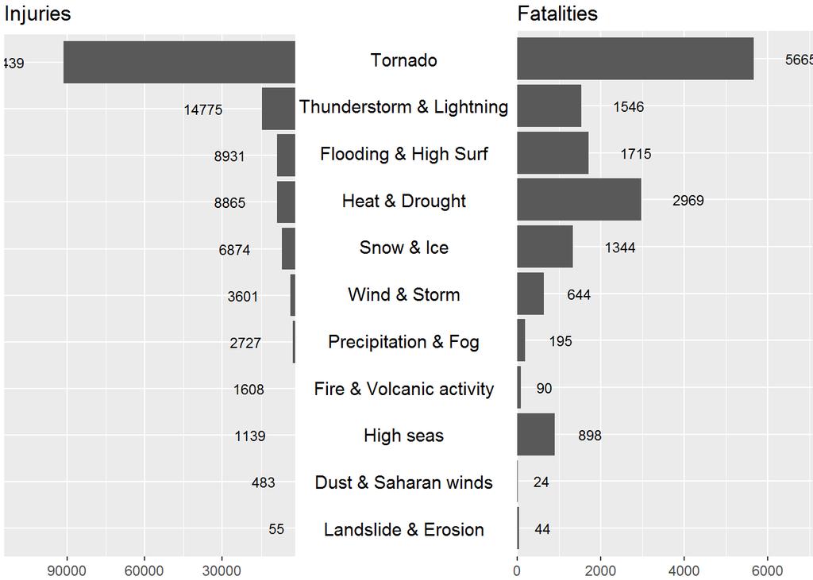

```r
# define max values for bar chart scale
maxInjuries <- max(summaryPopHealth$totalInjuries)
maxInjuries <- maxInjuries + round(maxInjuries * 0.25)

maxFatalities <- max(summaryPopHealth$totalDeaths)
maxFatalities <- maxFatalities + round(maxFatalities * 0.25)

# add middle column with just damageSource labels
g.mid <- ggplot(data=summaryPopHealth, aes(x=1,y=reorder(damageSource,totalInjuries))) +
  geom_text(aes(label=damageSource), size=4) +
  ggtitle("") +
  ylab(NULL) +
  scale_x_continuous(expand=c(0,0),limits=c(0.94,1.065)) +
  theme(axis.title=element_blank(),
        panel.grid=element_blank(),
        axis.text.y=element_blank(),
        axis.ticks.y=element_blank(),
        panel.background=element_blank(),
        axis.text.x=element_text(color=NA),
        axis.ticks.x=element_line(color=NA),
        plot.margin = unit(c(1,-1,1,-1), "mm"))

# add left chart with injuries
g.injuries <- ggplot(data=summaryPopHealth, aes(x=reorder(damageSource, totalInjuries), y=totalInjuries)) +
  geom_bar(stat = "identity") +
  geom_text(aes(label=totalInjuries), size=3, vjust=0.5, hjust=2.0) +
  ggtitle("Injuries") +
  scale_y_reverse(expand=c(0, 0), limits=c(maxInjuries,0)) +
  coord_flip() +
  theme(axis.title.x = element_blank(),
        axis.title.y = element_blank(),
        axis.text.y = element_blank(),
        axis.ticks.y = element_blank(),
        plot.margin = unit(c(1,-1,1,0), "mm"))

# add right chart with fatalities
g.fatalities <- ggplot(data=summaryPopHealth, aes(x= reorder(damageSource, totalInjuries), y=totalDeaths)) +
  geom_bar(stat = "identity") +
  geom_text(aes(label=totalDeaths), size=3, vjust=0.5, hjust=-1.0) +
  ggtitle("Fatalities") +
  scale_y_continuous(expand=c(0, 0), limits=c(0,maxFatalities)) +
  coord_flip() +
  theme(axis.title.x = element_blank(),
        axis.title.y = element_blank(),
        axis.text.y = element_blank(),
        axis.ticks.y = element_blank(),
        plot.margin = unit(c(1,0,1,-1), "mm"))

# combine charts in one plot
gg.injuries <- ggplot_gtable(ggplot_build(g.injuries))
gg.fatalities <- ggplot_gtable(ggplot_build(g.fatalities))
gg.mid <- ggplot_gtable(ggplot_build(g.mid))

grid.arrange(gg.injuries,gg.mid,gg.fatalities, ncol=3,widths=c(0.4,0.3,0.4))
```

The underlying data

```r
summaryPopHealth
```

```
## # A tibble: 11 x 3
##                damageSource totalInjuries totalDeaths
##                       <chr>         <dbl>       <dbl>
##  1                  Tornado         91439        5665
##  2 Thunderstorm & Lightning         14775        1546
##  3     Flooding & High Surf          8931        1715
##  4           Heat & Drought          8865        2969
##  5               Snow & Ice          6874        1344
##  6             Wind & Storm          3601         644
##  7      Precipitation & Fog          2727         195
##  8 Fire & Volcanic activity          1608          90
##  9                High seas          1139         898
## 10     Dust & Saharan winds           483          24
## 11      Landslide & Erosion            55          44
```

### 3.2 Across the United States, which types of events have the greatest economic consequences?

First need to create the summary dataset.

```r
summaryDamage <- cleanStormData %>%
  filter(!is.na(damageSource)) %>%
  group_by(damageSource) %>%
  summarise(totalDamage = sum(totalDamage)
  ) %>%
  arrange(desc(totalDamage))
```

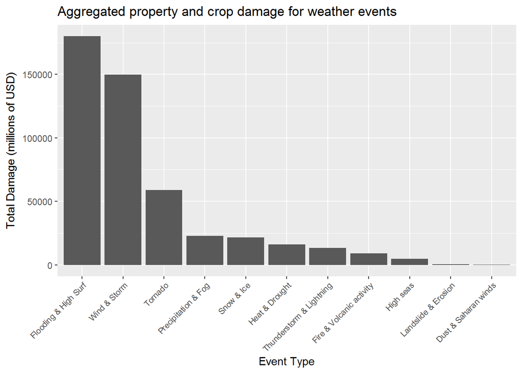

```r
ggplot(summaryDamage, aes(x=reorder(damageSource,-totalDamage), y=totalDamage/1000000)) +
  geom_bar(stat = "identity") +
  xlab("Event Type") +
  theme(axis.text.x = element_text(angle = 45, size=8, hjust = 1, vjust = 1)) +
  ylab("Total Damage (millions of USD)") +
  ggtitle("Aggregated property and crop damage for weather events")
```

The underlying data

```r
summaryDamage
```

```
## # A tibble: 11 x 2
##                damageSource  totalDamage
##                       <chr>        <dbl>
##  1     Flooding & High Surf 180093664782
##  2             Wind & Storm 149674819693
##  3                  Tornado  59020342849
##  4      Precipitation & Fog  22954342006
##  5               Snow & Ice  21427833113
##  6           Heat & Drought  15933954580
##  7 Thunderstorm & Lightning  13193641181
##  8 Fire & Volcanic activity   8905510130
##  9                High seas   4856460540
## 10      Landslide & Erosion    348279100
## 11     Dust & Saharan winds      9937630
```